# Pet adoption in Malaysia

Ryan Keen & Katherine (Guilin) Li

12/10/2019

# What are the important predictors for pet adoption speed in shelter in Malaysia?

##### A study of PetFinder.my data - Malaysia

##### December 2019

### Overview and Motivation

Each year, millions of dogs and cats are abandoned, abused, neglected, and ultimately placed in shelters where they await adoption. With that, it is extremely important to understand that pets are adopted are very different rates based on a variety of factors. Once the waiting process has exceeded a substantial amount of time, the placement process often times no longer seems to be feasible for these animals, and thus, there is a common move to euthanize the animal. This is often decided in an attempt to prevent deteriorating the health of the animal or to end any suffering or trauma that may be inflicted upon the animal as a result of residing in a shelter. Additionally, euthanization is often used to prevent exploiting an animal’s poor health and/or condition for fundraising purposes or brand enhancement for animal welfare groups. It has been shown that animal adoption rates are strongly correlated with the quality and quantity of information available to those who seek to adopt pets, such as photograph quality, texts, breed, color, etc. While many believe that euthanasia is the best possible option in numerous scenarios where animals reside in shelters for long periods of time, it may be better to use a more comprehensive approach to inform this decision. One possible way to better inform the aspects of this decision would analyzing the rate of adoption for animals that are placed in shelters. PetFinder.my has grown as a hub for those seeking to adopt a pet in Malaysia that centralizes all of the available information on more than 16,000 pets that are currently homeless. PetFinder.my has compiled this information into a comprehensive dataset that can be used to understand the factors that influence adoption. Using this information would be exceptionally useful in educating the public on the importance of adopting pets in shelters, rather than purchasing from stores. Furthermore, it could be used to inform adoption agencies on best practices for advertising pet profiles to increase the likelihood of adoption in order to avoid outcomes such as euthanasia.

### Related Work:

After connecting with the diverse networks of students at the Harvard Chan School of Public Health, we found a common theme among cohorts of students was the adoption of pets to provide them with support and company while pursuing academia. After exploring this topic further through various ongoing conversations, we decided to explore pet adoption as a potential topic for this project. Learning of the different practices surrounding pet adoption in a variety of counties around the world, we began seeking data on these rates and influencing factors. Finally, we found that PetFinder.my in Malaysia has created and maintained one of the most comprehensive pet adoption datasets to data, and thus decided to explore, visusalize and analyze the dataset.

### Initial Questions:

- Can we make a prediction model to predict the adoptability of pets?
- What are the important predictors of adoptability of pets, based on the dataset we have obtained?
- Are certain colors favored for pets in the shelter for adoption? Does it differ fot cats and dogs?
- Do gender, age, and pure breed affect pets adoptability?

### Dataset inspection and management

From the initial inspection of the data, it was found that there were no missing values in the dataset. As the original variables are mostly in a numerical form, including categorical ones, we first turned categorical variables from numerical to factors, with explanatory labels added to some important variables. As there was a vast number of nuanced breeds of both dogs and cats, we created a new variable to indicate if a pet is of pure breed or mixed breed, and that was included in the prediction models to represent breed. We also created a binary indicator for being adopted within 100 days (1) vs beyond 100 days (0), as the outcome of prediction models. We created a new age variable which was a conversion age from month to year with 0.5 correction for zero values, as we will use the log scale of age in visualization. We also dropped variables of Rescuer ID and Pet ID as they do not include much information.

```r
skim(proj_data)
```

Data summary

| Name | proj_data |
| --- | --- |
| Number of rows | 14993 |
| Number of columns | 24 |
| _______________________ |  |
| Column type frequency: |  |
| factor | 4 |
| numeric | 20 |
| ________________________ |  |
| Group variables | None |

**Variable type: factor**

| skim_variable | n_missing | complete_rate | ordered | n_unique | top_counts |
| --- | --- | --- | --- | --- | --- |
| Name | 0 | 1 | FALSE | 9061 | emp: 1257, Bab: 66, Luc: 64, Bro: 54 |
| RescuerID | 0 | 1 | FALSE | 5595 | fa9: 459, aa6: 315, c00: 231, b53: 228 |
| Description | 0 | 1 | FALSE | 14033 | For: 164, Dog: 54, Cat: 25, Fri: 20 |
| PetID | 0 | 1 | FALSE | 14993 | 000: 1, 000: 1, 000: 1, 001: 1 |

**Variable type: numeric**

| skim_variable | n_missing | complete_rate | mean | sd | p0 | p25 | p50 | p75 | p100 | hist |
| --- | --- | --- | --- | --- | --- | --- | --- | --- | --- | --- |
| Type | 0 | 1 | 1.46 | 0.50 | 1 | 1 | 1 | 2 | 2 | ▇▁▁▁▇ |
| Age | 0 | 1 | 10.45 | 18.16 | 0 | 2 | 3 | 12 | 255 | ▇▁▁▁▁ |
| Breed1 | 0 | 1 | 265.27 | 60.06 | 0 | 265 | 266 | 307 | 307 | ▁▁▁▁▇ |
| Breed2 | 0 | 1 | 74.01 | 123.01 | 0 | 0 | 0 | 179 | 307 | ▇▁▁▁▂ |
| Gender | 0 | 1 | 1.78 | 0.68 | 1 | 1 | 2 | 2 | 3 | ▆▁▇▁▂ |
| Color1 | 0 | 1 | 2.23 | 1.75 | 1 | 1 | 2 | 3 | 7 | ▇▁▁▁▁ |
| Color2 | 0 | 1 | 3.22 | 2.74 | 0 | 0 | 2 | 6 | 7 | ▇▆▃▂▇ |
| Color3 | 0 | 1 | 1.88 | 2.98 | 0 | 0 | 0 | 5 | 7 | ▇▁▁▁▃ |
| MaturitySize | 0 | 1 | 1.86 | 0.55 | 1 | 2 | 2 | 2 | 4 | ▂▇▁▁▁ |
| FurLength | 0 | 1 | 1.47 | 0.60 | 1 | 1 | 1 | 2 | 3 | ▇▁▅▁▁ |
| Vaccinated | 0 | 1 | 1.73 | 0.67 | 1 | 1 | 2 | 2 | 3 | ▆▁▇▁▂ |
| Dewormed | 0 | 1 | 1.56 | 0.70 | 1 | 1 | 1 | 2 | 3 | ▇▁▅▁▂ |
| Sterilized | 0 | 1 | 1.91 | 0.57 | 1 | 2 | 2 | 2 | 3 | ▂▁▇▁▂ |
| Health | 0 | 1 | 1.04 | 0.20 | 1 | 1 | 1 | 1 | 3 | ▇▁▁▁▁ |
| Quantity | 0 | 1 | 1.58 | 1.47 | 1 | 1 | 1 | 1 | 20 | ▇▁▁▁▁ |
| Fee | 0 | 1 | 21.26 | 78.41 | 0 | 0 | 0 | 0 | 3000 | ▇▁▁▁▁ |
| State | 0 | 1 | 41346.03 | 32.44 | 41324 | 41326 | 41326 | 41401 | 41415 | ▇▁▁▁▃ |
| VideoAmt | 0 | 1 | 0.06 | 0.35 | 0 | 0 | 0 | 0 | 8 | ▇▁▁▁▁ |
| PhotoAmt | 0 | 1 | 3.89 | 3.49 | 0 | 2 | 3 | 5 | 30 | ▇▁▁▁▁ |
| AdoptionSpeed | 0 | 1 | 2.52 | 1.18 | 0 | 2 | 2 | 4 | 4 | ▁▆▇▆▇ |

```r
proj_data <- proj_data %>% mutate(adspeed_bin = (AdoptionSpeed != 4) )

cols <- c("Breed1", "Breed2", "Gender", "Color1", "Color2", "Color3", "MaturitySize", "FurLength", "Vaccinated", "Dewormed", "Sterilized", "Health", "State", "adspeed_bin", "Type")

#proj_data2 <- proj_data

proj_data2 <- select(proj_data,-c(PetID,RescuerID))

proj_data2 %<>% mutate_each_(funs(factor(.)),cols)

proj_data2$AdoptionSpeed <- factor(proj_data2$AdoptionSpeed,
                                   levels = c(0,1,2,3,4),
                                   labels = c("Same Day", "Between 1 and 7 days",
                                              "Between 8 and 30 days", "Between 31 and 90 Days",
                                              "No Adoption After 100 Days"))

proj_data2 <- proj_data2 %>% mutate(purebreed = Breed2==0)

proj_data2 <- proj_data2 %>% mutate(age_adjusted_years = (Age + 0.5)/12)

proj_data2$Gender <- factor(proj_data2$Gender,
                    levels = c(1,2,3),
                    labels = c("Male", "Female", "Mixed"))

proj_data2$Type <- factor(proj_data2$Type,
                            levels = c(1,2),
                            labels = c("Dog", "Cat"))

proj_data2$purebreed <- factor(proj_data2$purebreed,
                          levels = c(FALSE,TRUE),
                          labels = c("Mixed Breed", "Pure Breed"))

proj_data2$Color1 <- factor(proj_data2$Color1,
                            levels = c(1,2,3,4,5,6,7),
                            labels = c("Black", "Brown",
                                       "Golden", "Yellow",
                                       "Cream", "Gray", "White"))
#summary(proj_data2)
skim(proj_data2)
```

Data summary

| Name | proj_data2 |
| --- | --- |
| Number of rows | 14993 |
| Number of columns | 25 |
| _______________________ |  |
| Column type frequency: |  |
| factor | 19 |
| numeric | 6 |
| ________________________ |  |
| Group variables | None |

**Variable type: factor**

| skim_variable | n_missing | complete_rate | ordered | n_unique | top_counts |
| --- | --- | --- | --- | --- | --- |
| Type | 0 | 1 | FALSE | 2 | Dog: 8132, Cat: 6861 |
| Name | 0 | 1 | FALSE | 9061 | emp: 1257, Bab: 66, Luc: 64, Bro: 54 |
| Breed1 | 0 | 1 | FALSE | 176 | 307: 5927, 266: 3634, 265: 1258, 299: 342 |
| Breed2 | 0 | 1 | FALSE | 135 | 0: 10762, 307: 1727, 266: 599, 265: 321 |
| Gender | 0 | 1 | FALSE | 3 | Fem: 7277, Mal: 5536, Mix: 2180 |
| Color1 | 0 | 1 | FALSE | 7 | Bla: 7427, Bro: 3750, Gol: 947, Cre: 884 |
| Color2 | 0 | 1 | FALSE | 7 | 0: 4471, 7: 3438, 2: 3313, 5: 1128 |
| Color3 | 0 | 1 | FALSE | 6 | 0: 10604, 7: 3221, 5: 417, 6: 378 |
| MaturitySize | 0 | 1 | FALSE | 4 | 2: 10305, 1: 3395, 3: 1260, 4: 33 |
| FurLength | 0 | 1 | FALSE | 3 | 1: 8808, 2: 5361, 3: 824 |
| Vaccinated | 0 | 1 | FALSE | 3 | 2: 7227, 1: 5898, 3: 1868 |
| Dewormed | 0 | 1 | FALSE | 3 | 1: 8397, 2: 4815, 3: 1781 |
| Sterilized | 0 | 1 | FALSE | 3 | 2: 10077, 1: 3101, 3: 1815 |
| Health | 0 | 1 | FALSE | 3 | 1: 14478, 2: 481, 3: 34 |
| State | 0 | 1 | FALSE | 14 | 413: 8714, 414: 3845, 413: 843, 413: 507 |
| Description | 0 | 1 | FALSE | 14033 | For: 164, Dog: 54, Cat: 25, Fri: 20 |
| AdoptionSpeed | 0 | 1 | FALSE | 5 | No : 4197, Bet: 4037, Bet: 3259, Bet: 3090 |
| adspeed_bin | 0 | 1 | FALSE | 2 | TRU: 10796, FAL: 4197 |
| purebreed | 0 | 1 | FALSE | 2 | Pur: 10762, Mix: 4231 |

**Variable type: numeric**

| skim_variable | n_missing | complete_rate | mean | sd | p0 | p25 | p50 | p75 | p100 | hist |
| --- | --- | --- | --- | --- | --- | --- | --- | --- | --- | --- |
| Age | 0 | 1 | 10.45 | 18.16 | 0.00 | 2.00 | 3.00 | 12.00 | 255.00 | ▇▁▁▁▁ |
| Quantity | 0 | 1 | 1.58 | 1.47 | 1.00 | 1.00 | 1.00 | 1.00 | 20.00 | ▇▁▁▁▁ |
| Fee | 0 | 1 | 21.26 | 78.41 | 0.00 | 0.00 | 0.00 | 0.00 | 3000.00 | ▇▁▁▁▁ |
| VideoAmt | 0 | 1 | 0.06 | 0.35 | 0.00 | 0.00 | 0.00 | 0.00 | 8.00 | ▇▁▁▁▁ |
| PhotoAmt | 0 | 1 | 3.89 | 3.49 | 0.00 | 2.00 | 3.00 | 5.00 | 30.00 | ▇▁▁▁▁ |
| age_adjusted_years | 0 | 1 | 0.91 | 1.51 | 0.04 | 0.21 | 0.29 | 1.04 | 21.29 | ▇▁▁▁▁ |

### Exploratory analysis

#### Shiny app for visualization

To visualize the data, we constructed a shiny app to generate two interactive ggplots. These plots analyzed age, base color of fur, type of animal (dog/cat), and breed status with respect to adoption speed: The first visualization shows adoption speeds, as indexed in the dataset stratified by gender, mixed vs. pure breed, dog vs. cat, and age in years. The second tab of the ShinyApp incorporate the geom_boxplot function and facet_grid functions to depict the rate of adoption by primary fur color of dogs and cats. Given the dataset was composed of more than 14,000 data point, we chose to use boxplots to depict the stratified data. Looking at all male animals, it is clear that, on average, the median age of animal that are not adopted after 100 days is higher than most other animals. Furthermore, faster adoptions tend to occurs with male animals that are younger. The data for male dogs, both pure breed and mixed breed, tends to be more spread out than that of male cats; this indicates that there is less variation in the adoption speed of male cats. For both male dogs and cats there is no clear evidence showing that the difference in adoption speeds is influence by breed status, whether mixed or pure.

The data for females dogs and cats is similar. However, there is less variation about the median ages for female animals. The “mixed” category shows the data to be very concentrated; this likely arises from the small (relative to single pet adoptions) number of pets that were adopted in groups. Therefore, there is insufficient evidence to form conclusions on this data.

The data on primary fur color indicates that the base coat of most animals in the dataset was black. The proportion of animals adopted, based on fur color, was relatively constant across dogs and cats after the same day adoption category. That being said, the low values are likely a result of a small number of animals classified with that fur color. While this is a general visualization, it would be better to collect data that is sufficient in order to do a survival analysis in which the event indicator is adoption.

```r
# Define UI for application that draws a histogram
ui <- fluidPage(theme = shinytheme("superhero"),
                titlePanel("Pet Adoption in Malaysia"),
                tabsetPanel(
                  tabPanel("Adoption Speed of Sheltered Dogs and Cats in Malaysia",
                sidebarLayout(
                  sidebarPanel(
                    p("The grid shows the adoption speeds of dogs and cats by breed status and age.
                      Please use the selection panel below to stratify the data by gender.
                      Note: a gender of 'mixed' status indicates the animals were adopted in groups."),
                    br(),
                    selectInput(inputId = "Gender", label = "Select Gender", choices = as.list(levels(proj_data2$Gender)))),
                  mainPanel(plotOutput("plot1")))),
                tabPanel("Adoption Speeds By Color",
                sidebarLayout(
                  sidebarPanel(
                    p("The panel to the right shows the count of dogs and cats stratified by the primary base color of their fur.
                      Please use drop down menu to visualize this data for each adoption speed."),
                    br(),
                    selectInput(inputId = "AdoptionSpeed", label = "Select Adoption Speed", choices = as.list(levels(proj_data2$AdoptionSpeed)))),
                  mainPanel(plotOutput("colorplot"))))))
# Define server logic required to draw a histogram
server <- function(input, output){
  Gender <- reactive(proj_data2 %>% filter(Gender == input$Gender))
  output$plot1 <- renderPlot({proj_data2 %>% filter(Gender == input$Gender) %>% ggplot() +
      theme(text = element_text(size=20, family = "Tahoma"), axis.text.x = element_text(angle = 65, hjust = 1, size=12)) + xlab("Adoption Speed") +
      ylab("Age in Years") + scale_y_continuous(trans = "log2") + geom_boxplot(aes(AdoptionSpeed, age_adjusted_years, fill = AdoptionSpeed)) +
      theme(legend.position = "none") + facet_grid(Type~purebreed)
  })

  output$colorplot <- renderPlot({proj_data2 %>% filter(AdoptionSpeed == input$AdoptionSpeed) %>% ggplot() +
      theme(text = element_text(size=20, family = "Tahoma"), axis.text.x = element_text(angle = 65, hjust = 1, size=12)) + xlab("Primary Color") +
      ylab("Count") + geom_bar(aes(Color1, fill = Color1)) + facet_grid(.~Type) +
      theme(legend.position = "none")})}

# Run the application
shinyApp(ui = ui, server = server)
```

Shiny applications not supported in static R Markdown documents

#### Word Cloud for visualization

The word cloud the most common descriptions and names used by the adoption agencies. Given that the most common pet names are common words such as “kittens” and “puppies,” this would indicate that the majority of pets in the dataset are unnamed, which may be an important factor in pet adoption speeds. For the descriptions of pets in adoption shelters, the most frequently used words were “home” and “please.” Ultimately, given the uniformity of names (of lack thereof) and descriptions, it was decided that using names and descriptions as predictors may not be an important predictor.

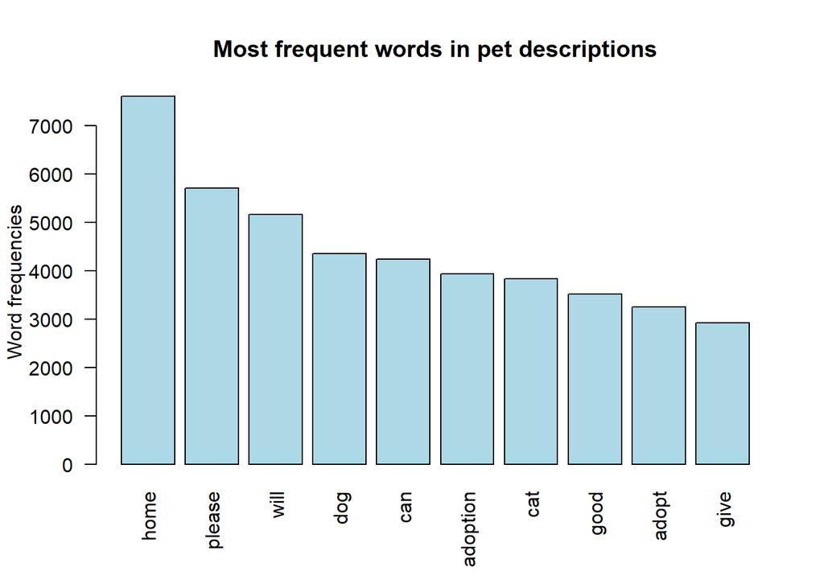

```r
text <- proj_data2$Description

# remove words with non-ASCII characters
dat1 <- grep("text", iconv(text, "latin1", "ASCII", sub="text"))
dat2 <- text[-dat1]

train_corpus = Corpus(VectorSource(text))
#transforming everything to lower case
train_corpus = tm_map(train_corpus, content_transformer(tolower))
#remove numbers and punctuations in the text
train_corpus = tm_map(train_corpus, removeNumbers)
train_corpus = tm_map(train_corpus, removePunctuation)
#remove words such as "the", "and"
train_corpus = tm_map(train_corpus, removeWords, c("the", "and", stopwords("english")))
train_corpus =  tm_map(train_corpus, stripWhitespace)
#print("Dimensions of our new X matrix:")
X <- DocumentTermMatrix(train_corpus)
#print(dim(X))

# print("First 10 rows and first 10 columns of our matrix:")
# inspect(X[1:10, 1:10])
frequency_cutoff = 0.97
X <- removeSparseTerms(X, frequency_cutoff)
# print("Dimensions of our new X matrix:")
# print(dim(X))

# print("First 10 rows and first 10 columns of our matrix:")
# inspect(X[1:10, 1:10])

m <- as.matrix(X)
v <- sort(colSums(m),decreasing=TRUE)
d <- data.frame(word = names(v),freq=v)
#head(d, 10)


barplot(d[1:10,]$freq, las = 2, names.arg = d[1:10,]$word,
        col ="lightblue", main ="Most frequent words in pet descriptions",
        ylab = "Word frequencies")
```

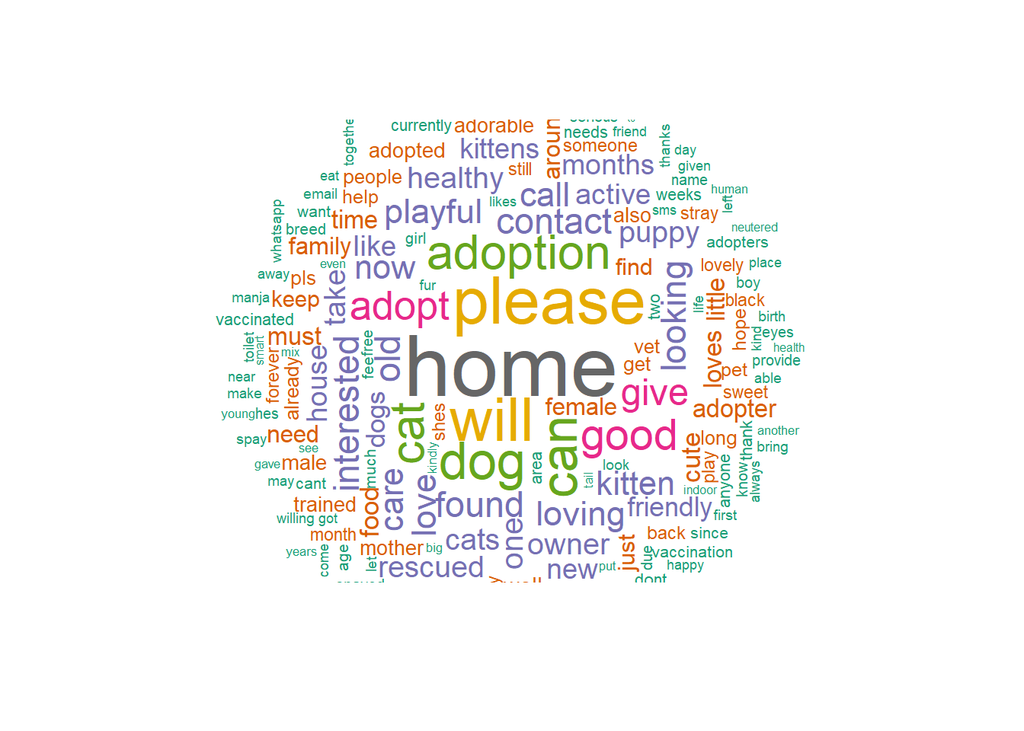

```r
set.seed(1234)
wordcloud(words = d$word, freq = d$freq, min.freq = 1,
          max.words=200, random.order=FALSE, rot.per=0.35,
          scale=c(3.5,0.3),colors=brewer.pal(8, "Dark2"))
```

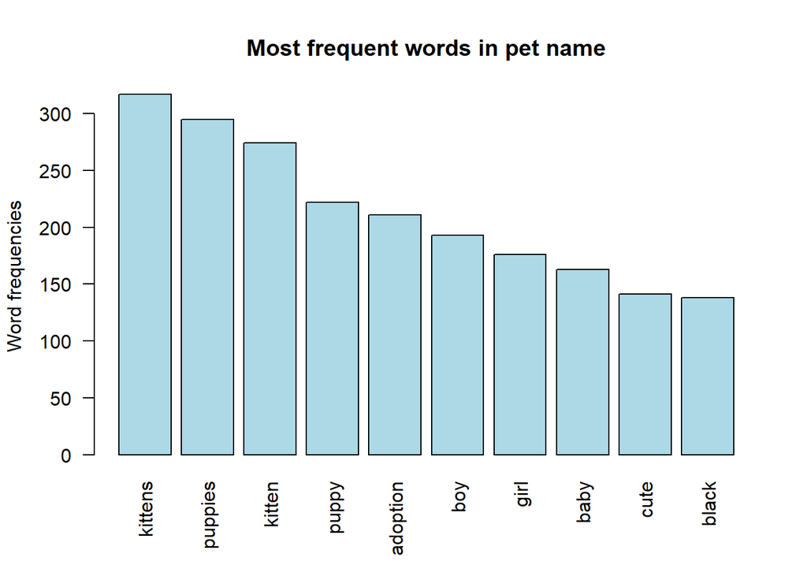

```r
####NAME####

text2 <- proj_data2$Name

# remove words with non-ASCII characters
dat3 <- grep("text", iconv(text2, "latin1", "ASCII", sub="text"))
dat4 <- text2[-dat3]

train_corpus = Corpus(VectorSource(dat4))
train_corpus = tm_map(train_corpus, content_transformer(tolower))
train_corpus = tm_map(train_corpus, removeNumbers)
train_corpus = tm_map(train_corpus, removePunctuation)
train_corpus = tm_map(train_corpus, removeWords, c("the", "and", stopwords("english")))
train_corpus =  tm_map(train_corpus, stripWhitespace)
#print("Dimensions of our new X matrix:")
X2 <- DocumentTermMatrix(train_corpus)
#print(dim(X2))

#print("First 10 rows and first 10 columns of our matrix:")
#inspect(X2[1:10, 1:10])
#frequency_cutoff = 0.95
#X <- removeSparseTerms(X, frequency_cutoff)
#print("Dimensions of our new X matrix:")
#print(dim(X))

# print("First 10 rows and first 10 columns of our matrix:")
# inspect(X[1:10, 1:10])

m2 <- as.matrix(X2)
v2 <- sort(colSums(m2),decreasing=TRUE)
d2 <- data.frame(word = names(v2),freq=v2)
#head(d2, 10)

barplot(d2[1:10,]$freq, las = 2, names.arg = d2[1:10,]$word,
        col ="lightblue", main ="Most frequent words in pet name",
        ylab = "Word frequencies")
```

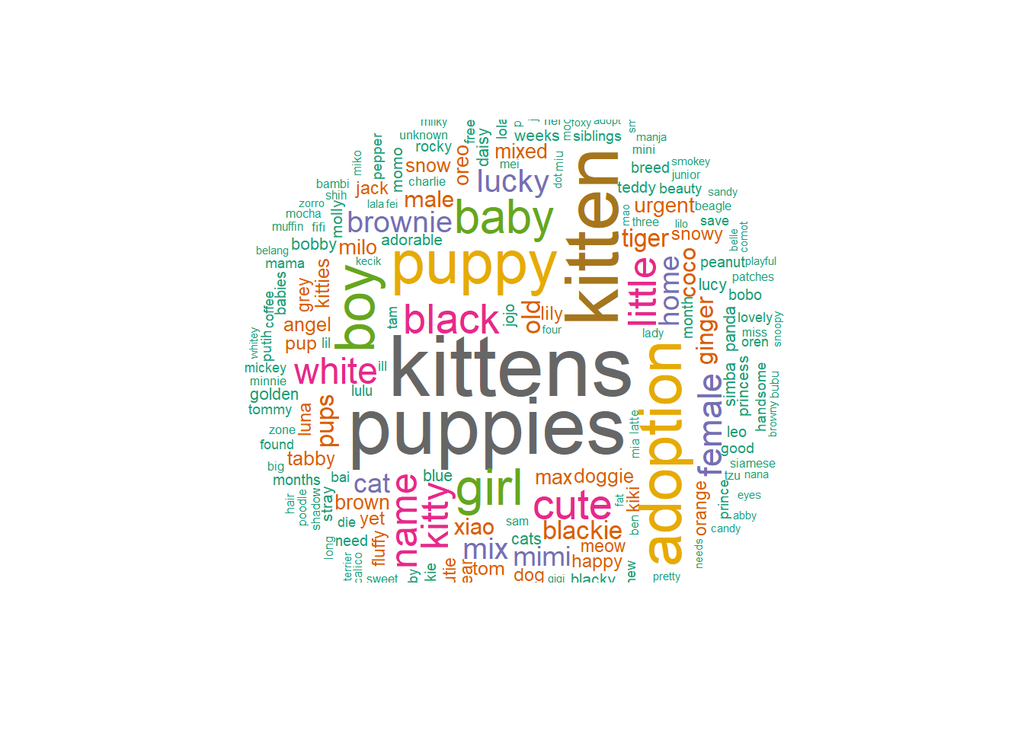

```r
set.seed(1234)
wordcloud(words = d2$word, freq = d2$freq, min.freq = 1,
          max.words=200, random.order=FALSE, rot.per=0.35, scale=c(3.5,0.3),
          colors=brewer.pal(8, "Dark2"))
```

### Prediction Model

We used Random Forest and Lasso methods to build two models to predict binary adoption speed (adopted within 100 days vs. beyond 100 days).

First we splitted the data into training dataset and test dataset randomly in 8:2 ratio. The training dataset was used for building the model, and the test dataset was used to evaluate the model performance.

```r
set.seed(16327)
trainIndex <- createDataPartition(proj_data2$adspeed_bin, p = 0.8,
                                  list = FALSE,
                                  times = 1)
#head(trainIndex)

adopt_train <- proj_data2[ trainIndex,]
adopt_test  <- proj_data2[-trainIndex,]
```

#### Random Forest Classifier

We fitted random forest model in the training dataset with all available variables except for name, IDs, transformed age, description, and the original breed variables due to a large amount of levels. Variable importance plot was provided to present the most important predictors of adoptability. AUC value on the test set was calculated as an evaluation of model performance (discrimination).

```r
rf.adopt = randomForest(adspeed_bin~.-Name-Description-AdoptionSpeed-Breed1-Breed2-age_adjusted_years,data = adopt_train)
imp <- as.data.frame(varImpPlot(rf.adopt))
```

```r
#importance(rf.adopt)
```

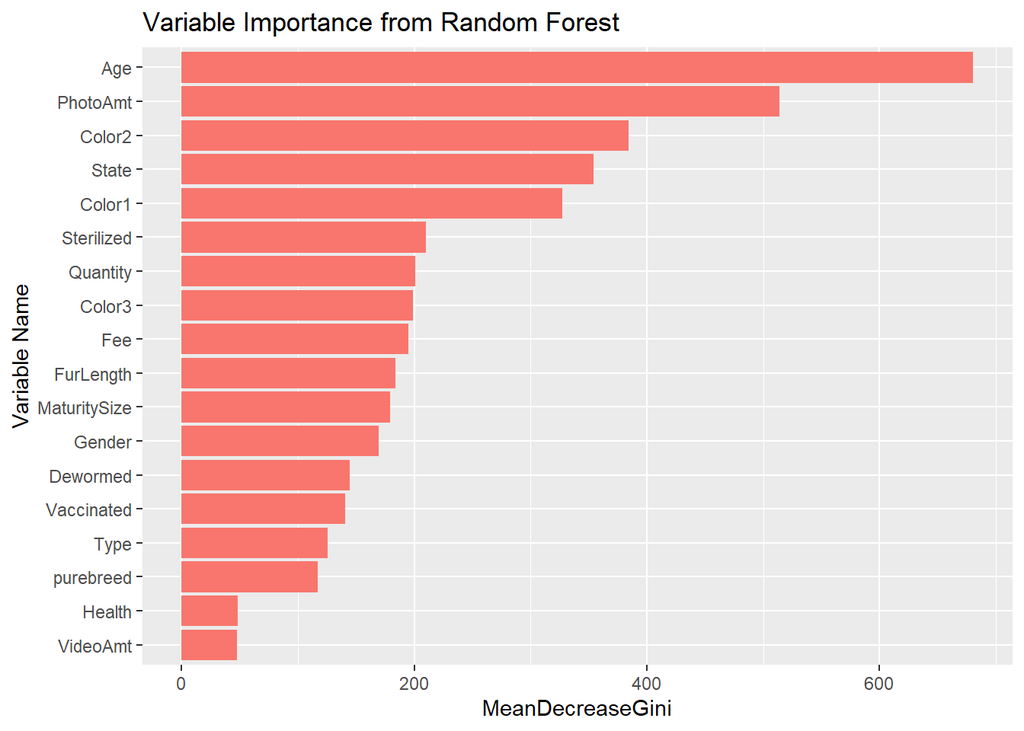

```r
imp$varnames <- rownames(imp) # row names to column

ggplot(imp, aes(fill="#FF6666",x=reorder(varnames, MeanDecreaseGini), weight=MeanDecreaseGini)) +
  geom_bar() +
  scale_fill_discrete() +
  ylab("MeanDecreaseGini") +
  xlab("Variable Name") +coord_flip() + theme(legend.position = "none") + ggtitle("Variable Importance from Random Forest")
```

```r
pred_test_rf <- predict(rf.adopt,adopt_test,type="prob")[,2]
pred_test_rf<-as.numeric(pred_test_rf)
roc_test_rf<- roc(response =adopt_test$adspeed_bin, predictor=pred_test_rf)
roc_test_rf
```

```
##
## Call:
## roc.default(response = adopt_test$adspeed_bin, predictor = pred_test_rf)
##
## Data: pred_test_rf in 839 controls (adopt_test$adspeed_bin FALSE) < 2159 cases (adopt_test$adspeed_bin TRUE).
## Area under the curve: 0.7473
```